# Luiz de Oliveira Alves Filho

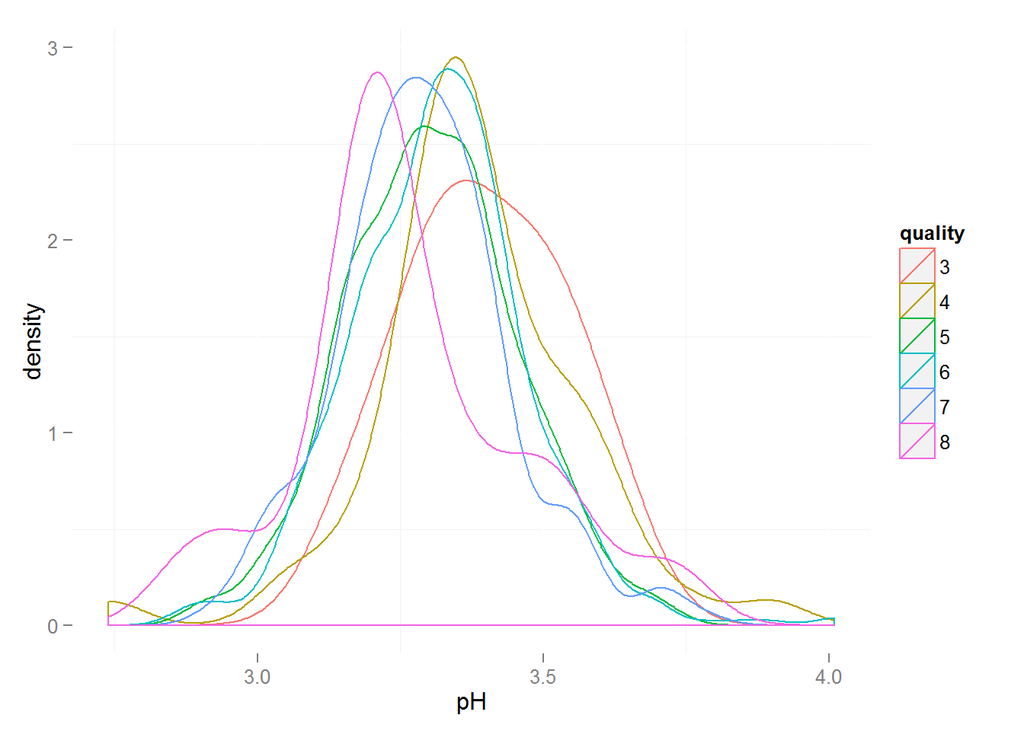

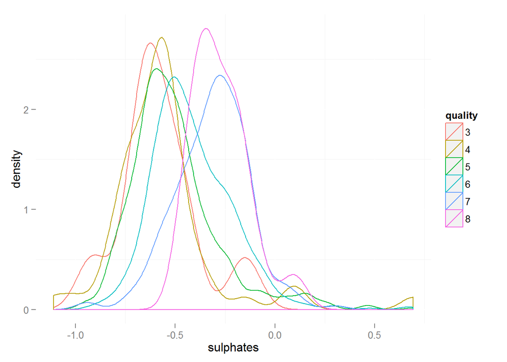

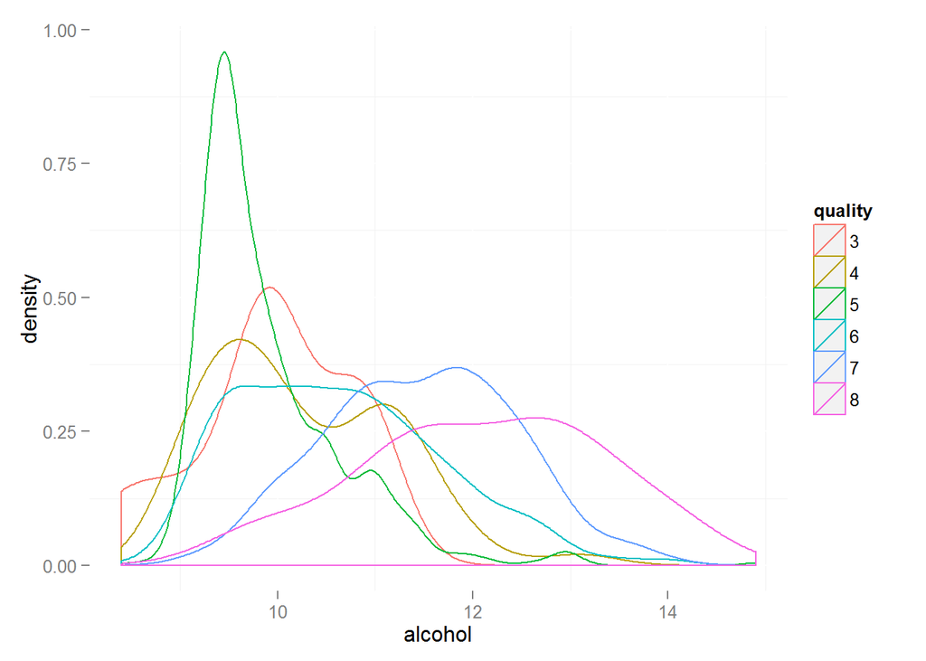

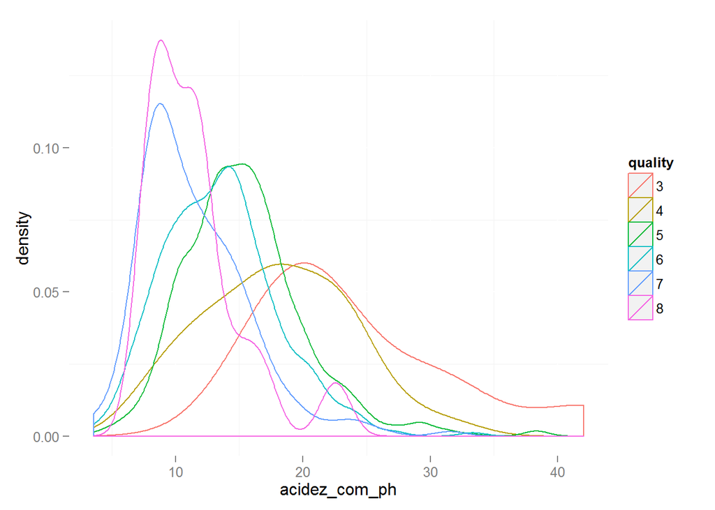

```
## [1] "É possível observar a distribuição enviesando para a direita para o citric.acid, sulphates e alcohol.  Essa relação inverte para esquerda por meio do pH, acidez_com_ph e volatile.acidity, como já foi evidenciado anteriormente por meio dos box plots."
```

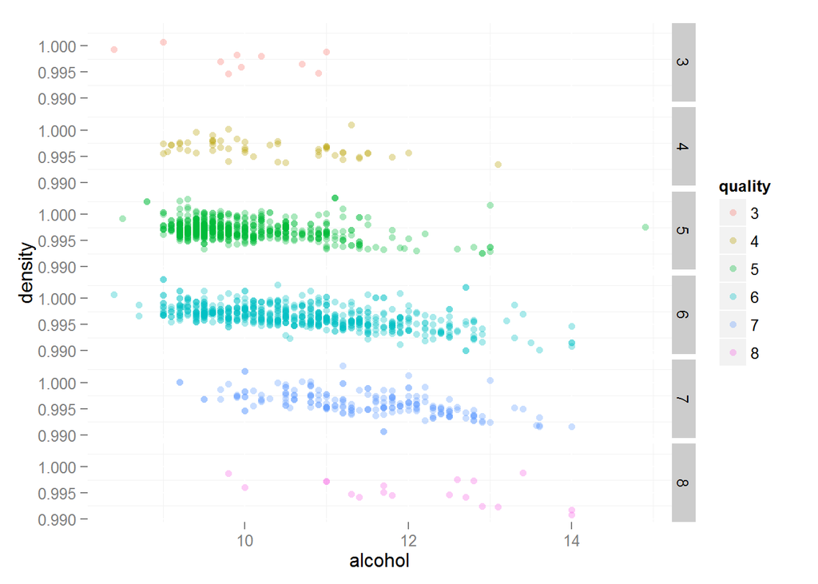

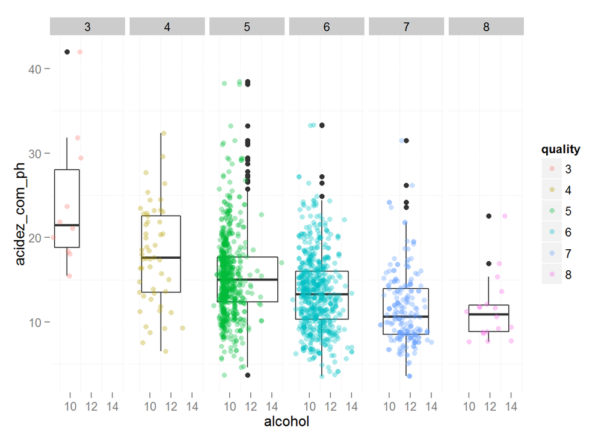

```
## [1] "Sumário: alcohol para todas as avaliações"
```

```
##   Group.1 x.Min. x.1st Qu. x.Median x.Mean x.3rd Qu. x.Max.
## 1       3  8.400     9.725    9.925  9.955    10.580 11.000
## 2       4  9.000     9.600   10.000 10.270    11.000 13.100
## 3       5  8.500     9.400    9.700  9.900    10.200 14.900
## 4       6  8.400     9.800   10.500 10.630    11.300 14.000
## 5       7  9.200    10.800   11.500 11.470    12.100 14.000
## 6       8  9.800    11.320   12.150 12.090    12.880 14.000
```

```
## [1] "Sumário: density para todas as avaliações"
```

```
##   Group.1 x.Min. x.1st Qu. x.Median x.Mean x.3rd Qu. x.Max.
## 1       3 0.9947    0.9962   0.9976 0.9975    0.9988 1.0010
## 2       4 0.9934    0.9956   0.9965 0.9965    0.9974 1.0010
## 3       5 0.9926    0.9962   0.9970 0.9971    0.9979 1.0030
## 4       6 0.9901    0.9954   0.9966 0.9966    0.9979 1.0040
## 5       7 0.9906    0.9948   0.9958 0.9961    0.9974 1.0030
## 6       8 0.9908    0.9942   0.9949 0.9952    0.9972 0.9988
```

```
## [1] "Sumário: acidez_com_ph para todas as avaliações"
```

```
##   Group.1 x.Min. x.1st Qu. x.Median x.Mean x.3rd Qu. x.Max.
## 1       3 15.470    18.810   21.490 24.200    28.020 42.030
## 2       4  6.534    13.530   17.660 17.940    22.540 32.390
## 3       5  3.722    12.390   15.020 15.380    17.710 38.500
## 4       6  3.580    10.310   13.310 13.480    16.020 33.330
## 5       7  3.642     8.522   10.640 11.510    13.950 31.520
## 6       8  7.674     8.849   10.950 11.450    12.020 22.560
```

```
## [1] "Sumário: chlorides para todas as avaliações"
```

```
##   Group.1  x.Min. x.1st Qu. x.Median  x.Mean x.3rd Qu.  x.Max.
## 1       3 0.06100   0.07900  0.09050 0.12250   0.14300 0.26700
## 2       4 0.04500   0.06700  0.08000 0.09068   0.08900 0.61000
## 3       5 0.03900   0.07400  0.08100 0.09274   0.09400 0.61100
## 4       6 0.03400   0.06825  0.07800 0.08496   0.08800 0.41500
## 5       7 0.01200   0.06200  0.07300 0.07659   0.08700 0.35800
## 6       8 0.04400   0.06200  0.07050 0.06844   0.07550 0.08600
```

```
##    previsao_dados_baleanceados
##      4  5  6  7  8
##   4 10  5  2  1  0
##   5  1 14  2  1  0
##   6  0  4 10  1  3
##   7  0  2  4  7  5
##   8  0  0  1  0 17
```

```
##    previsao_toda_a_base_de_dados_acima_de_nota_3
##       4   5   6   7   8
##   4  21  15  11   5   1
##   5  80 222 222 131  26
##   6  36 134 196 161 111
##   7   9  20  35  46  89
##   8   0   0   1   0  17
```

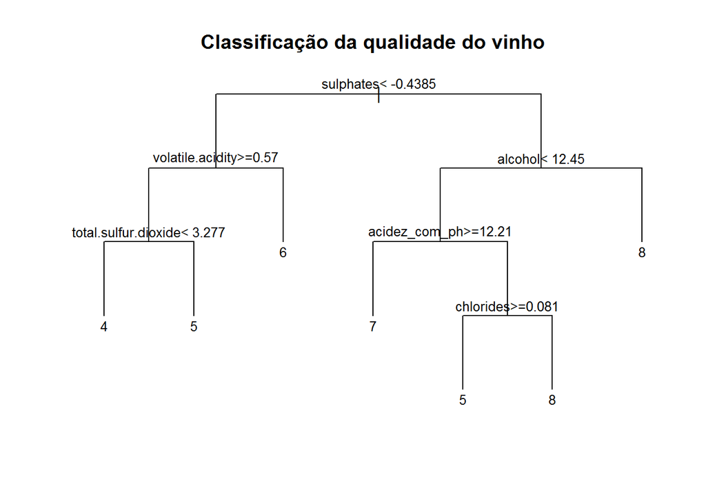

```
## [1] "Acurácia dos dados para treinamento do modelo:"
```

```
## [1] 64.44444
```

```
## [1] "Acurácia dos dados para base de dados com todas as avaliações acima de nota 3:"
```

```
## [1] 31.5922
```

# Multivariate Analysis

### Talk about some of the relationships you observed in this part of the investigation. Were there features that strengthened each other in terms of looking at your feature(s) of interest?

A medida que a density diminui e alcohol aumenta, as avaliações tendem a ser melhores. Já quando a acidez_com_ph aumenta e o alcohol diminue, a qualidade tende a piorar, a grande maioria dos vinhos que receberam nota 5 possuem alcohol abaixo de 11, a medida que esse teor aumenta e a acidez diminui, as avaliações vão melhorando. Reafirmando tudo que já foi encontrado até agora.

### Were there any interesting or surprising interactions between features?

Eu esperava que o residual.sugar possuísse importância para a definição das avaliações, mas surpreendetemente não se mostrou relevante. Porém, algumas outras informações se mostraram interessantes, a mediana do alcohol tende a aumentar com a qualidade do vinho, característica inversa quando tratado pela density, acidez_com_ph e chlorides.

### OPTIONAL: Did you create any models with your dataset? Discuss the strengths and limitations of your model.

Sim, criei uma árvore de decisão, uma de suas vantagens é a implementação simples e a possibilidade de resolver problemas de classificação. Como está desbalanceada (frequência das avaliações desproporcional que pode enviesar o modelo), defini pela quantidade de avaliações que deram nota 8. Desta maneira, foram extraídas aleatoriamente 18 avaliações para cada nota, com exceção à nota 3, por ter uma quantidade pequena de amostra, como o foco é descobrir as variáveis que auxiliam para definir um bom vinho, ela foi removida por essas razões.

Foi encontrada uma acurácia de 64% para os dados de treinamento e 31% para a base de dados com avaliações acima de 3, o uso desse modelo é importante porque exibe quais variáveis foram mais importantes para a classificação das notas, o sulphates, alcohol, acidez_com_ph e chlorides foram as mais representativas. A variável sulphates superou as expectativas, pois eu acreditava que o alcohol era a variável que melhor classificaria os vinhos bons dos ruins, papel feito de forma mais eficiente pelos sulphates.

# Final Plots and Summary

### Plot One

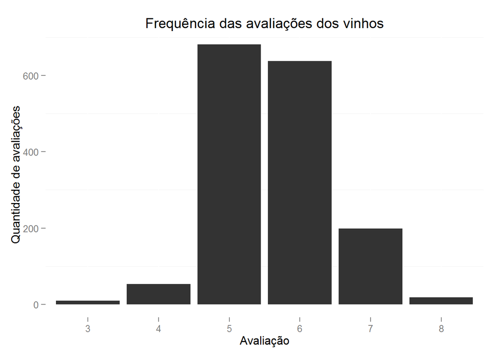

### Description One

Com a frequência das avaliações é possível perceber o desbalanceamento da base de dados. De avaliações entre 1 e 10, ela possui apenas 60% das notas, dessas, 83% estão alocadas para duas notas, compromentendo a análise.

### Plot Two

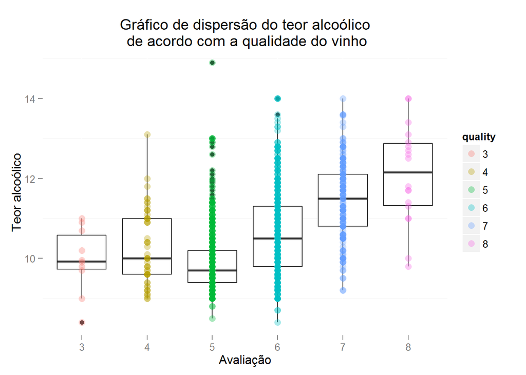

### Description Two

A variável que possuiu maior correlação linear positiva com a qualidade do vinho foi o alcohol, essa tendência crescente pode ser vista pelo box plot acima.

### Plot Three

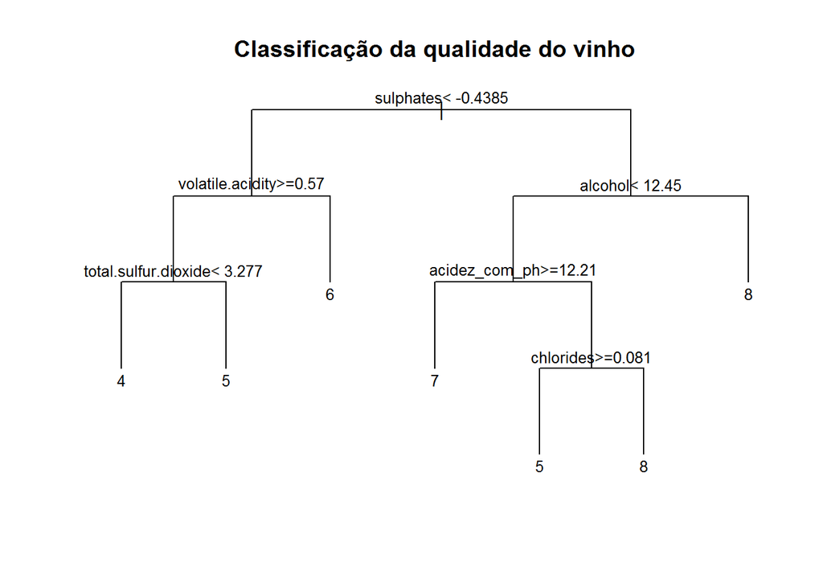

### Description Three

Os dados foram balanceados e um modelo de classificação utilizando árvore de decisão foi desenvolvido, as variáveis: sulphates, alcohol, acidez_com_ph e chlorides foram as melhores para essa categorização.

# Reflection

A amostra possui 1599 avaliações de vinhos, essas avaliações podem variar entre 0 a 10, porém, nessa base de dados possui apenas notas variando entre 3 e 8, ou seja, possui apenas 60% das possíveis notas. Poderia ser uma possibilidade, mas como não contém nem pelo menos um voto, pareceu problema na extração da base de dados. Outro problema é apresentado, 83% da base de dados é referente à duas notas, o que pode enviesar o modelo de classificação. Os dados foram balanceados e um modelo de árvore de decisão foi desenvolvido a fim de entender o objetivo desse estudo. Através dele, percebeu-se que os componentes químicos: sulphates, alcohol, acidez_com_ph e chlorides foram as melhores variáveis para essa avaliação de um vinho com qualidade, mas que devido ao problema da amostra, a acurácia não é eficiente, necessitando de melhorias.